# DataMining

TaeMinJeong

2022 4 22

## 1. 일상생활에서 볼 수 있는 Odds 사례

Odds란 성공대비 실패의 확률 비 이다. 만약 자유투를 하는 경우 스테판 커리의 자유투 성공률이 90퍼센트라고 한다면, 이때 커리의 자유투 승산은 1/9 이다.  
이 뿐만 아니라, 고려대 김승섭 교수팀의 체감 일자리 불안과 우울증의 연관성 관련 기사를 확인하면 “현대자동차 정규직 판매직원 560명의 건강 상태를 7년의 시차를 두고 추적해 보니 일자리가 불안하다고 느끼는 사람들의 우울증 발병 위험은 그렇지 않은 사람들에 비해 3배 가까이 높았다” 라는 부분에서 3배 가까이 높았다는 부분은 실제 기사에서는 2.74의 승산비로 나타난다.

## 2. 선형회귀분석

### 1) 데이터 수집 및 전처리

선형회귀 분석에 사용한 Data Set은 Kaggle에 존재하는 Data Set으로 차의 가격을 예측하는데 사용하는 모델이다. R studio에 CarPrice라는 이름으로 CSV 파일을 불러왔다.

```r
carData <- read.csv("C:/Users/okchr/CarPrice.csv")
str(carData)
```

```
## 'data.frame':    205 obs. of  26 variables:
##  $ car_ID          : int  1 2 3 4 5 6 7 8 9 10 ...
##  $ symboling       : int  3 3 1 2 2 2 1 1 1 0 ...
##  $ CarName         : chr  "alfa-romero giulia" "alfa-romero stelvio" "alfa-romero Quadrifoglio" "audi 100 ls" ...
##  $ fueltype        : chr  "gas" "gas" "gas" "gas" ...
##  $ aspiration      : chr  "std" "std" "std" "std" ...
##  $ doornumber      : chr  "two" "two" "two" "four" ...
##  $ carbody         : chr  "convertible" "convertible" "hatchback" "sedan" ...
##  $ drivewheel      : chr  "rwd" "rwd" "rwd" "fwd" ...
##  $ enginelocation  : chr  "front" "front" "front" "front" ...
##  $ wheelbase       : num  88.6 88.6 94.5 99.8 99.4 ...
##  $ carlength       : num  169 169 171 177 177 ...
##  $ carwidth        : num  64.1 64.1 65.5 66.2 66.4 66.3 71.4 71.4 71.4 67.9 ...
##  $ carheight       : num  48.8 48.8 52.4 54.3 54.3 53.1 55.7 55.7 55.9 52 ...
##  $ curbweight      : int  2548 2548 2823 2337 2824 2507 2844 2954 3086 3053 ...
##  $ enginetype      : chr  "dohc" "dohc" "ohcv" "ohc" ...
##  $ cylindernumber  : chr  "four" "four" "six" "four" ...
##  $ enginesize      : int  130 130 152 109 136 136 136 136 131 131 ...
##  $ fuelsystem      : chr  "mpfi" "mpfi" "mpfi" "mpfi" ...
##  $ boreratio       : num  3.47 3.47 2.68 3.19 3.19 3.19 3.19 3.19 3.13 3.13 ...
##  $ stroke          : num  2.68 2.68 3.47 3.4 3.4 3.4 3.4 3.4 3.4 3.4 ...
##  $ compressionratio: num  9 9 9 10 8 8.5 8.5 8.5 8.3 7 ...
##  $ horsepower      : int  111 111 154 102 115 110 110 110 140 160 ...
##  $ peakrpm         : int  5000 5000 5000 5500 5500 5500 5500 5500 5500 5500 ...
##  $ citympg         : int  21 21 19 24 18 19 19 19 17 16 ...
##  $ highwaympg      : int  27 27 26 30 22 25 25 25 20 22 ...
##  $ price           : num  13495 16500 16500 13950 17450 ...
```

변수는 총 26개, 205개의 sample을 가지고 있다.  
각각의 변수에 대해서 알아보자.  
1. Car_ID : 모든 차의 고유 식별 번호(integer)  
2. Symboling : 할당된 보험 위험 등급. 낮을 수록 안전하다는 것을 의미한다. (categorical)  
3. carName : 자동차 이름 (categorical)  
4. fueltype : 자동차의 사용 연료. Gas or Diesel (categorical)  
5. aspiration : 자동차에 사용되는 흡입력(categorical)  
6. doornumber : 문의 개수 (categorical)  
7. carbody : 자동차의 몸체 (categorical)  
8. drivewheel : 구동되는 바퀴 (categorical)  
9. enginelocation : 엔진의 위치 (categorical)  
10. wheelbase : 차량의 휠베이스 (numeric)  
11. carlength : 차량의 길이 (numeric)  
12. carwidth : 차량의 넓이 (numeric)  
13. carheight : 차량의 높이 (numeric)  
14. carweight : 차량의 무게 (numeric)  
15. enginetype : 차량에 장착된 실린더(categorical)  
16. cylindernumber : 차량에 장착된 실린더(categorical)  
17. enginesize : 엔진의 크기 (numeric)  
18. fuelsystem : 자동차의 연료 시스템 (categorical) 19. boreratio : 차량의 보어 비율 (numeric) 20. stroke : 엔진 내부의 스트로크 또는 볼륨(numeric)  
21. compressionratio : 차량 압축률 (numeric)  
22. horsepower : 마력 (Numeric)  
23. peakrpm : 차량의 최대 rpm (Numeric)  
24. citympg : 시내 마일리지 (Numeric)  
25. highwaympg : 고속도로 마일리지 (Numeric) 26. price(Dependent variable) : 가격 (Numeric)

### 2) 탐색적 데이터 분석

범주형 범수와 정규화 스케일링을 하기전에 우선적으로 데이터 분석을 진행하도록 하겠다. 이때 car_ID는 단순히 index이며 CarName은 그에 따른 변화이므로 해당 데이터에서 제거 하기로 하였다.

```r
carData <- carData[,-c(1,3)] #car_ID, CarName 제거
str(carData)
```

[output not shown]

```r
#install.packages("ggplot2")

colSums(is.na(carData)) # null 값이 있는지 확인
```

```
##        symboling         fueltype       aspiration       doornumber
##                0                0                0                0
##          carbody       drivewheel   enginelocation        wheelbase
##                0                0                0                0
##        carlength         carwidth        carheight       curbweight
##                0                0                0                0
##       enginetype   cylindernumber       enginesize       fuelsystem
##                0                0                0                0
##        boreratio           stroke compressionratio       horsepower
##                0                0                0                0
##          peakrpm          citympg       highwaympg            price
##                0                0                0                0
```

```r
library(ggplot2)
names(carData)[1]
```

```
## [1] "symboling"
```

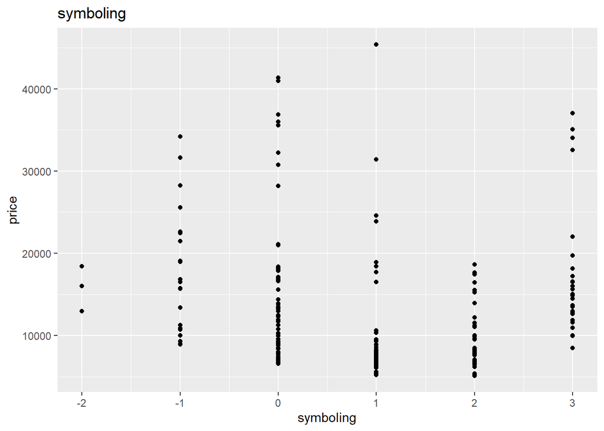

```r
#par(mfrow=c(2,1))
qplot(symboling , price , data = carData, main="symboling")
```

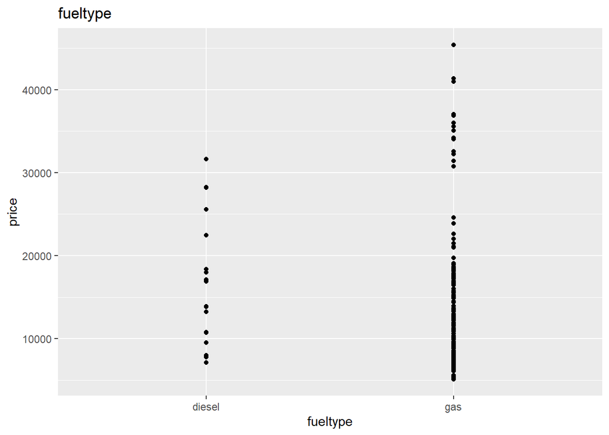

```r
qplot(fueltype, price , data = carData, main="fueltype")
```

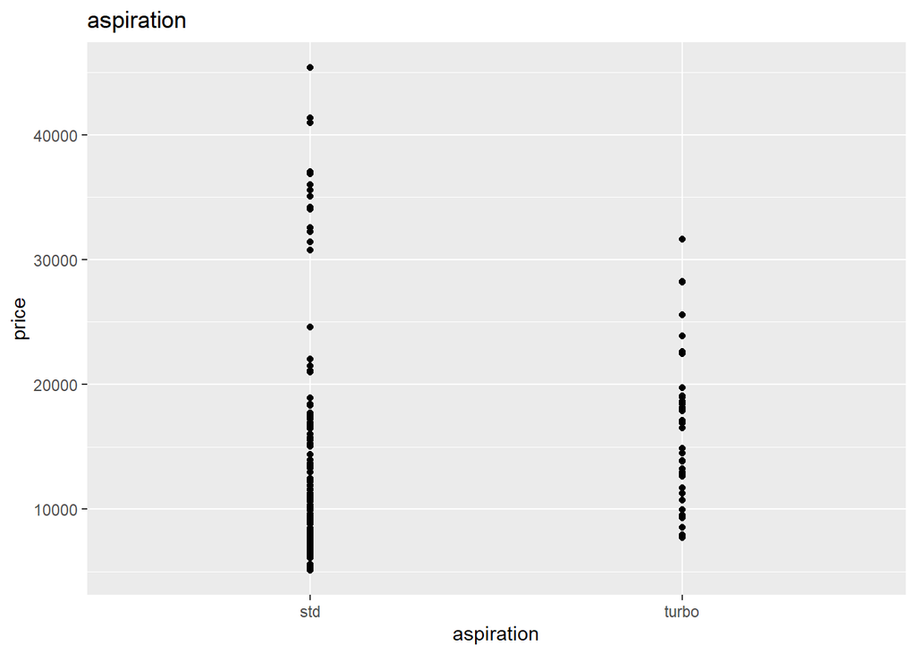

```r
qplot(aspiration, price , data = carData, main="aspiration")
```

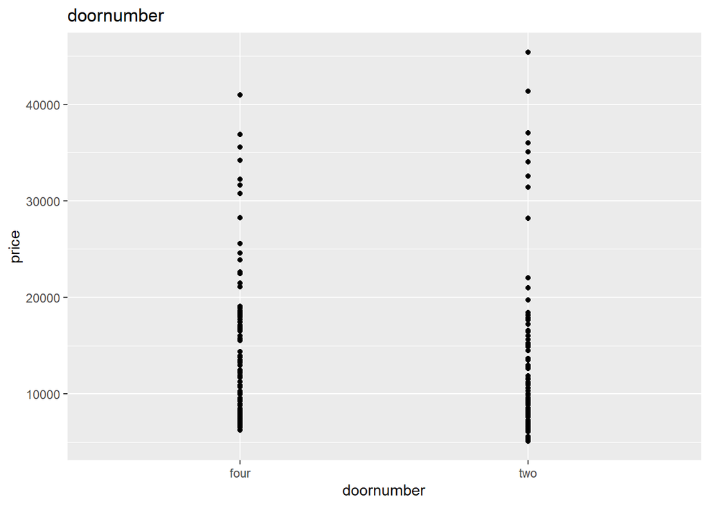

```r
qplot(doornumber , price , data = carData, main="doornumber")
```

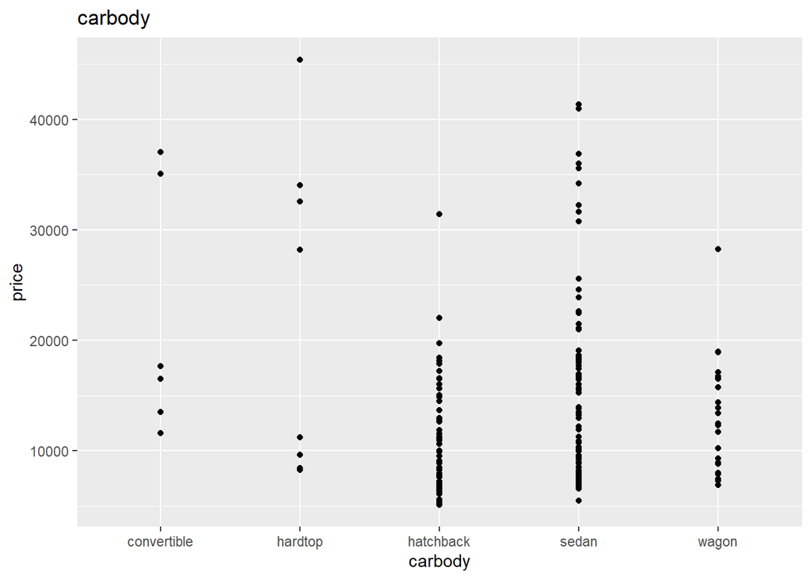

```r
qplot(carbody, price , data = carData, main="carbody")
```

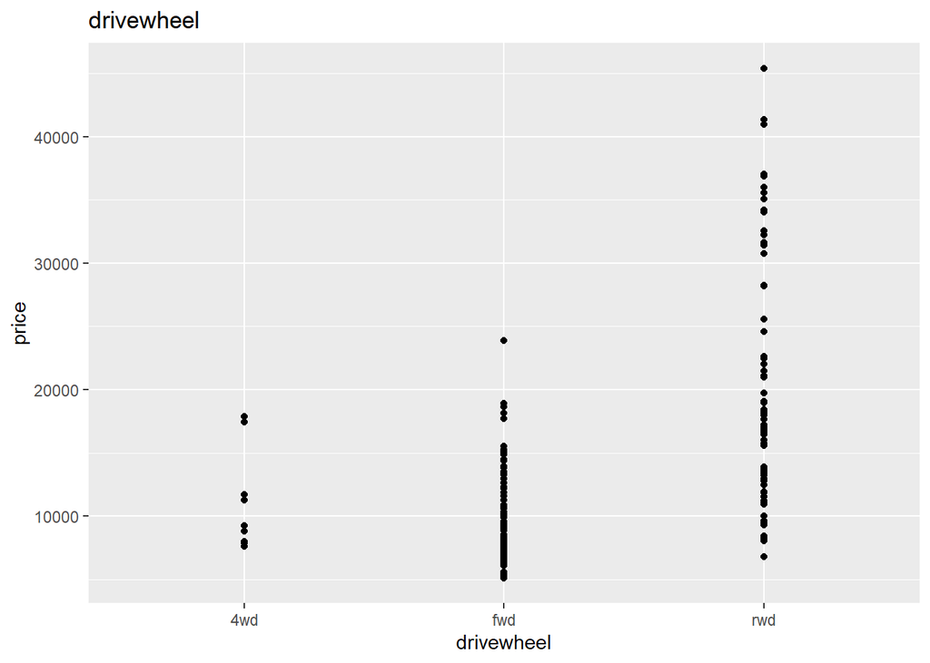

```r
qplot(drivewheel, price , data = carData, main="drivewheel")
```

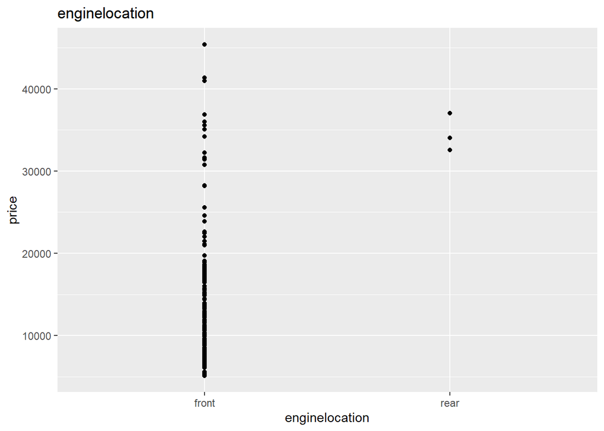

```r
qplot(enginelocation, price , data = carData, main="enginelocation")
```

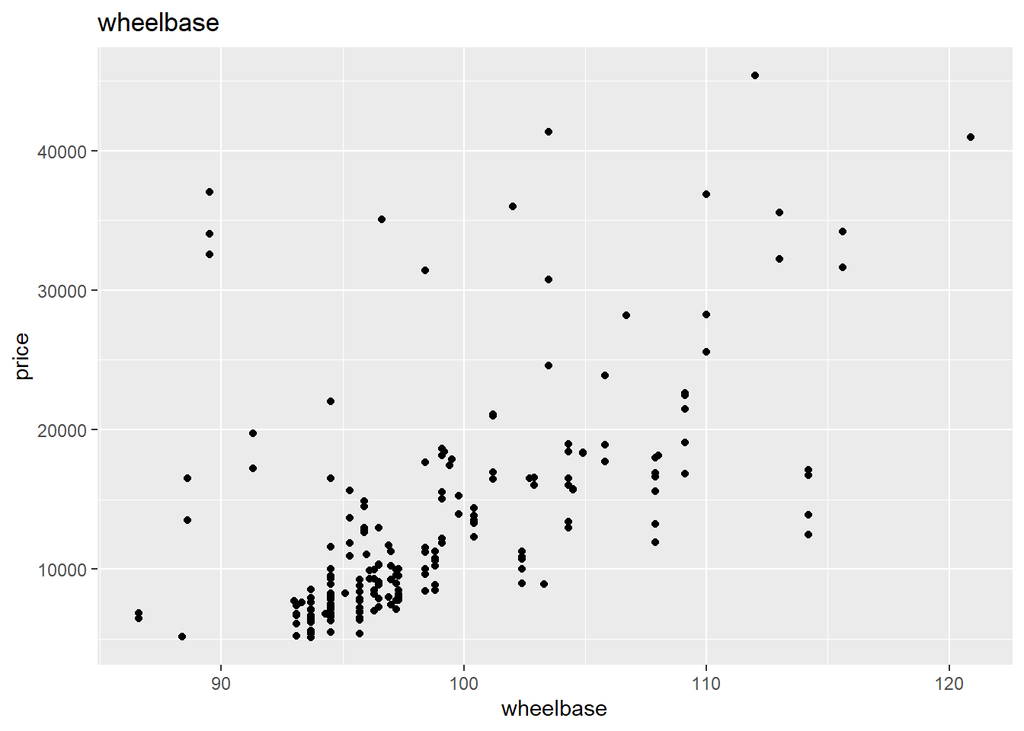

```r
qplot(wheelbase, price , data = carData, main="wheelbase")
```

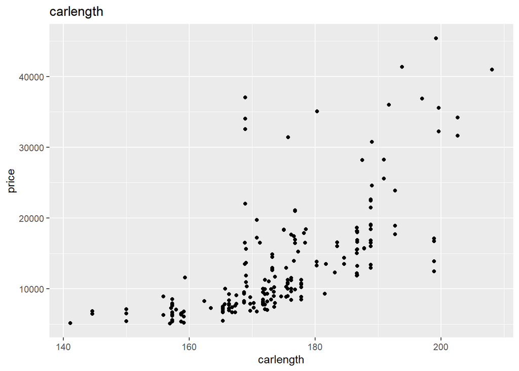

```r
qplot(carlength, price , data = carData, main="carlength")
```

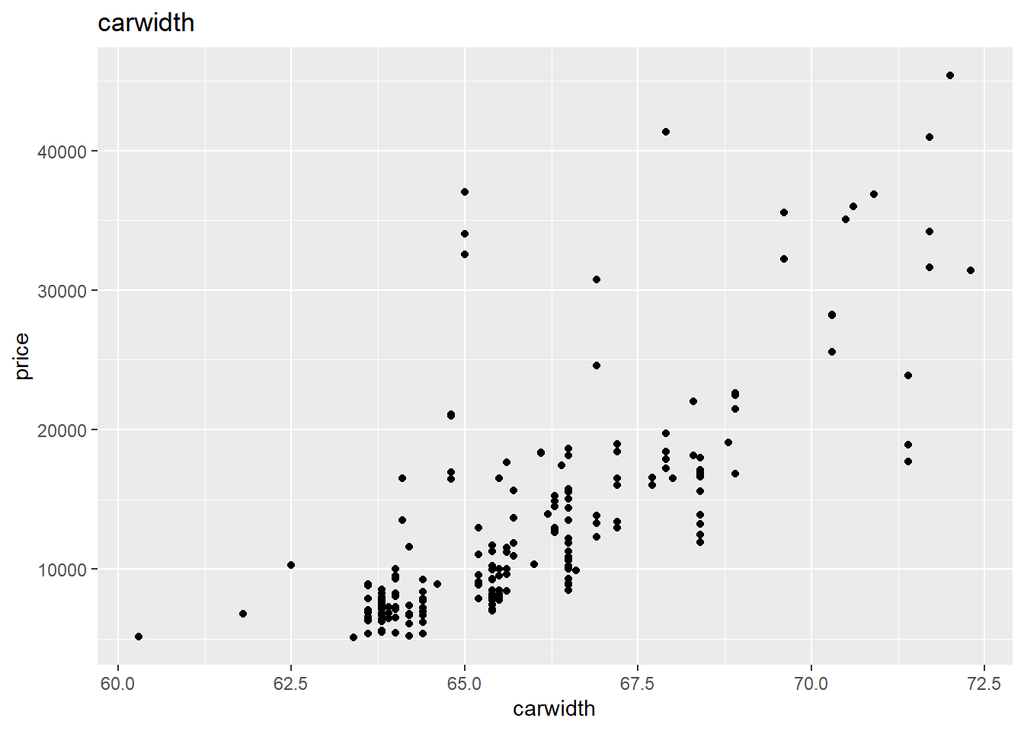

```r
qplot(carwidth, price , data = carData, main="carwidth")
```

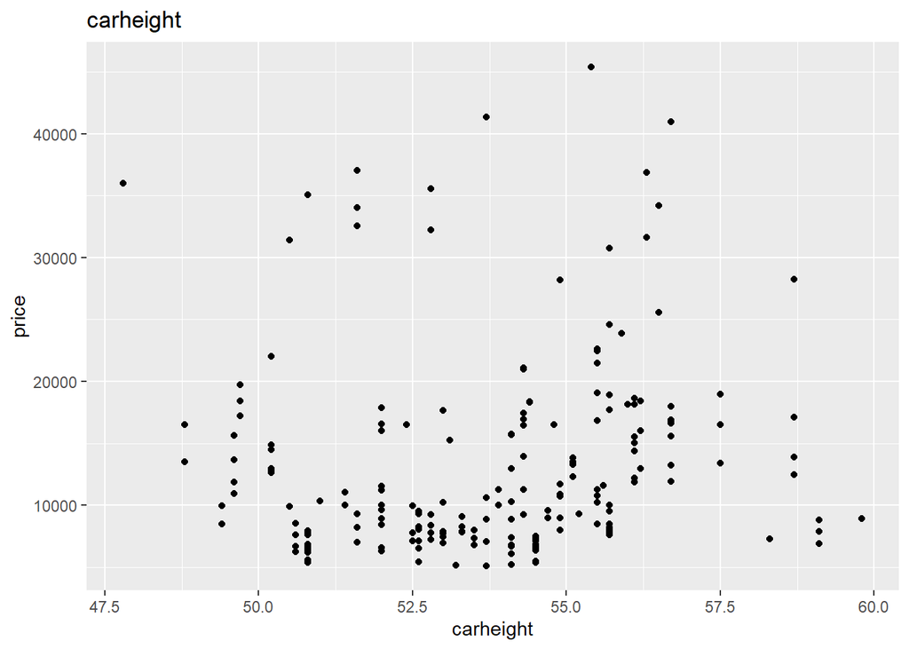

```r
qplot(carheight, price , data = carData, main="carheight")
```

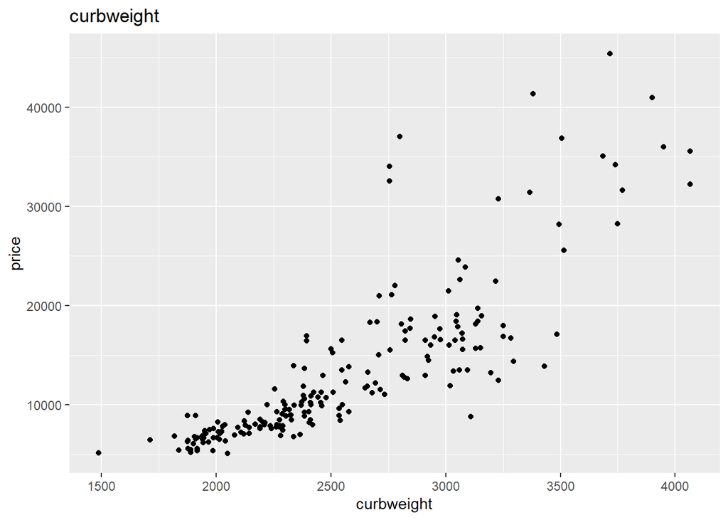

```r
qplot(curbweight, price , data = carData, main="curbweight")
```

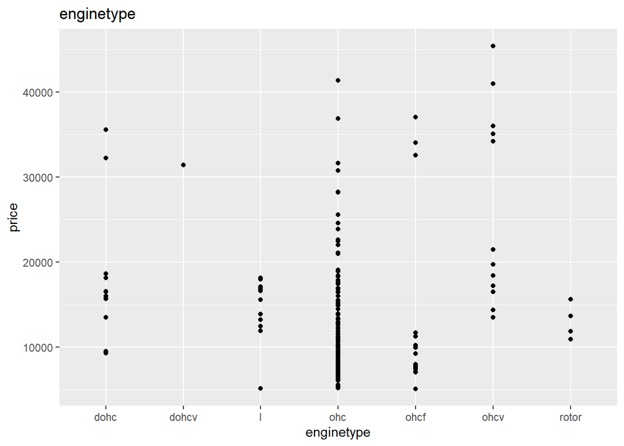

```r
qplot(enginetype, price , data = carData, main="enginetype")
```

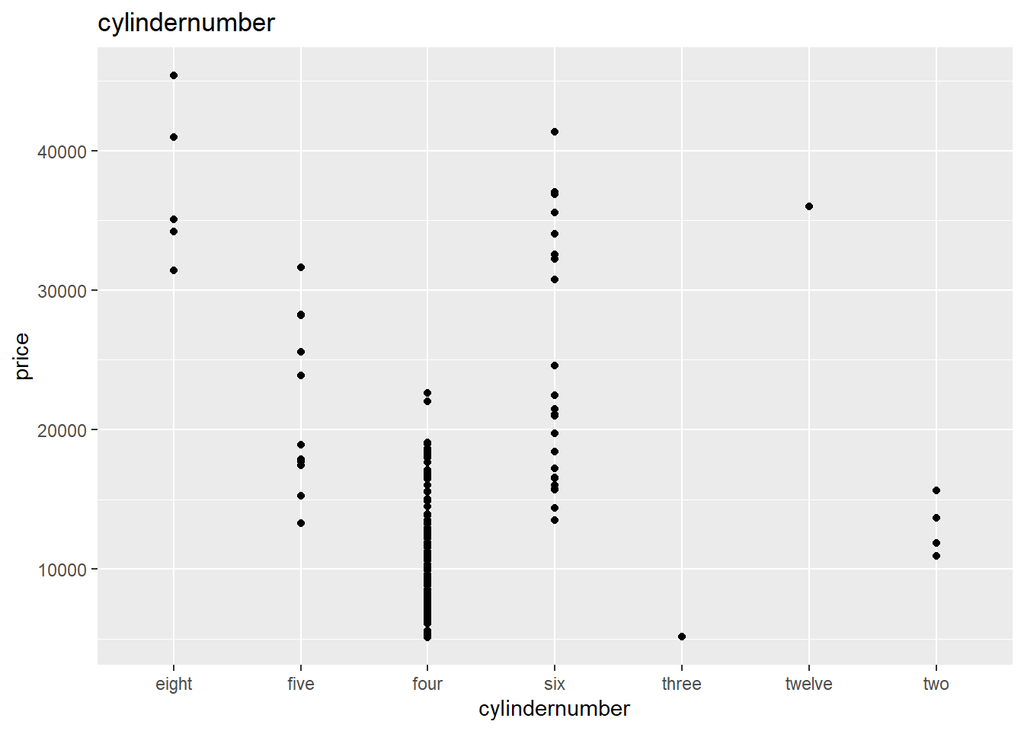

```r
qplot(cylindernumber, price , data = carData, main="cylindernumber")
```

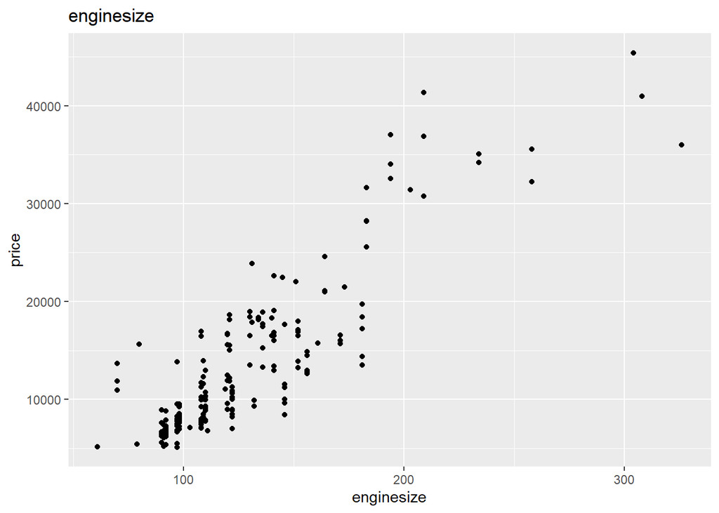

```r
qplot(enginesize, price , data = carData, main="enginesize")
```

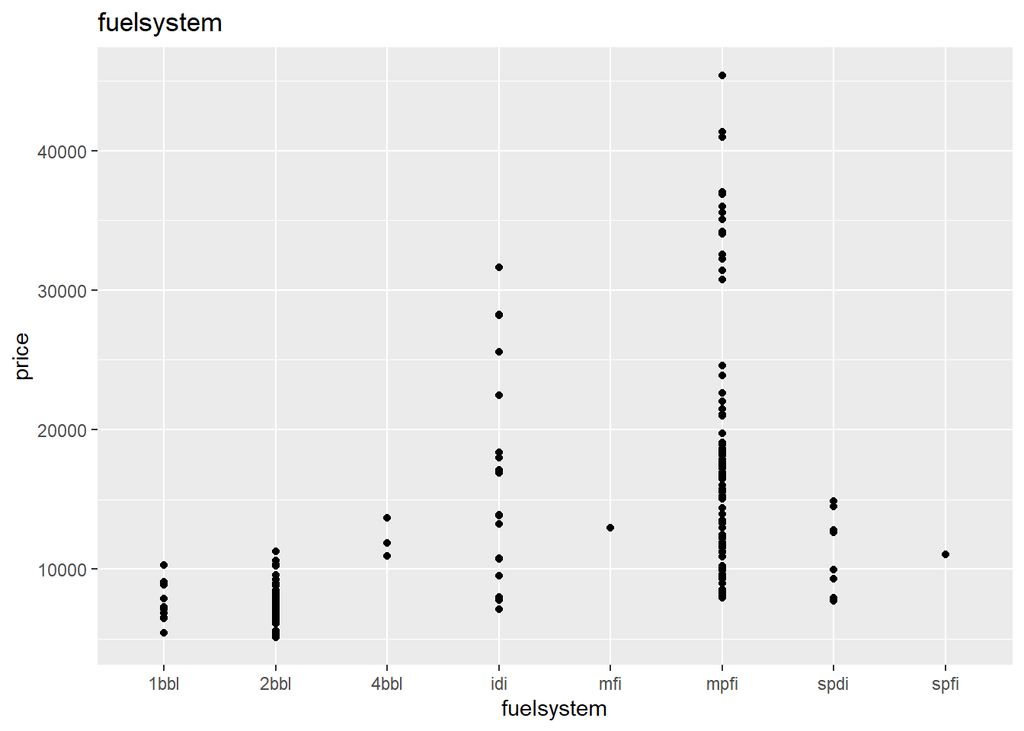

```r
qplot(fuelsystem, price , data = carData, main="fuelsystem")
```

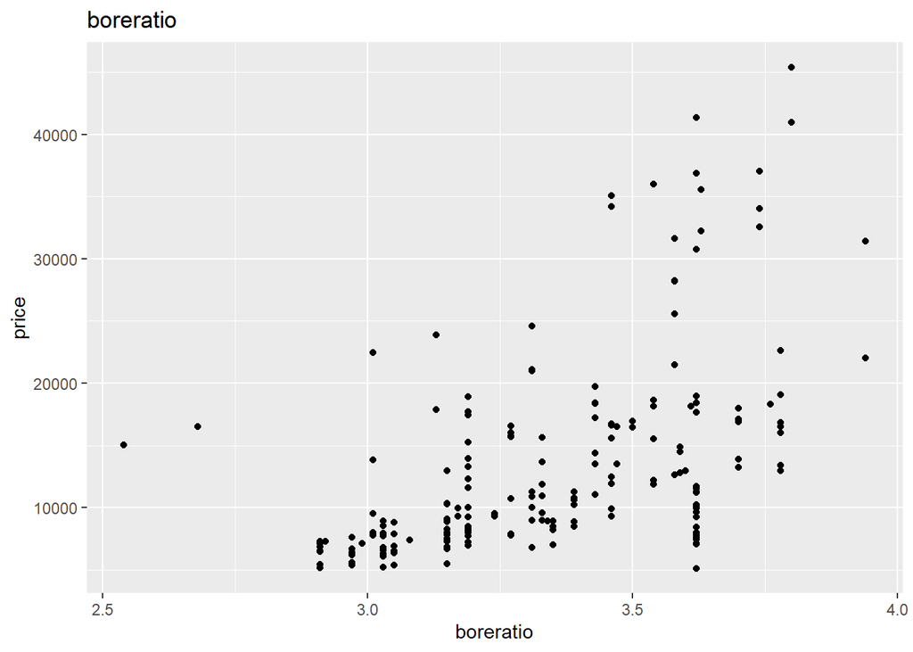

```r
qplot(boreratio, price , data = carData, main="boreratio")
```

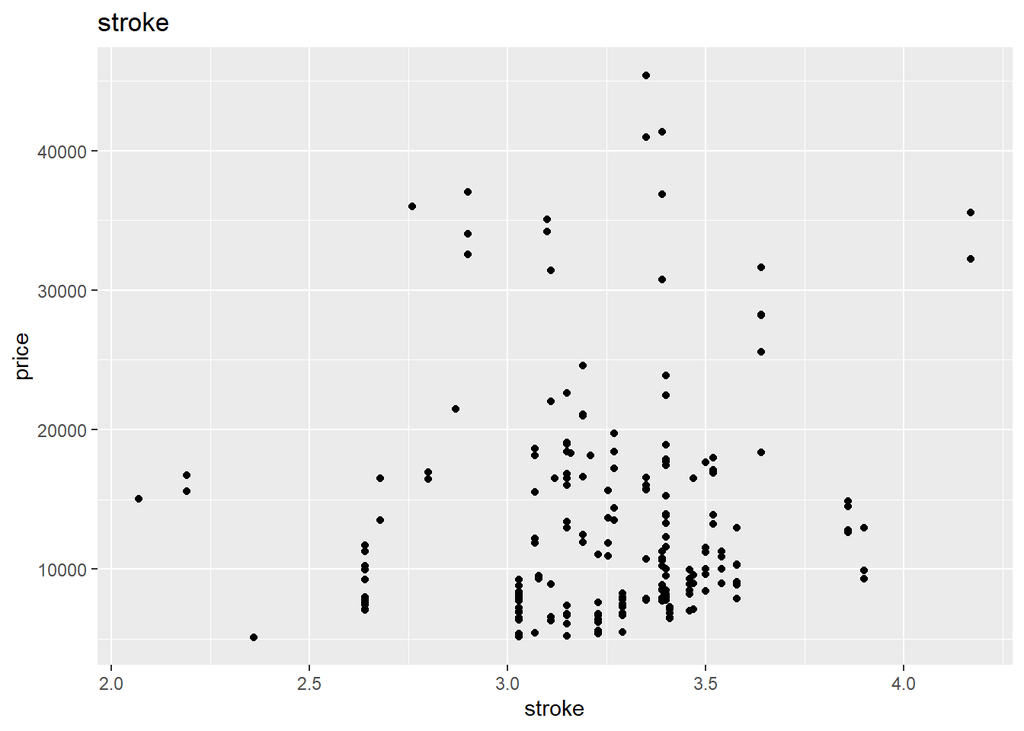

```r
qplot(stroke, price , data = carData, main="stroke")
```

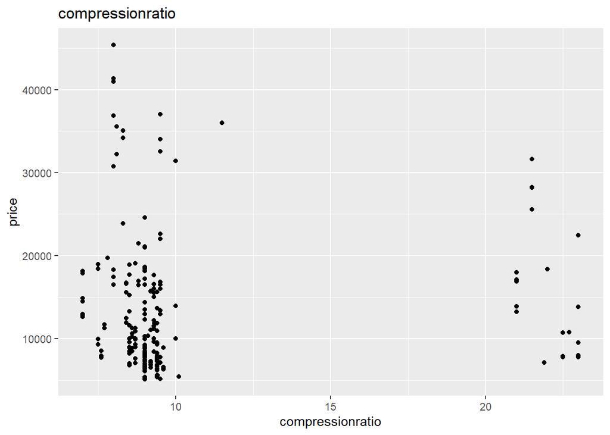

```r
qplot(compressionratio, price , data = carData, main="compressionratio")
```

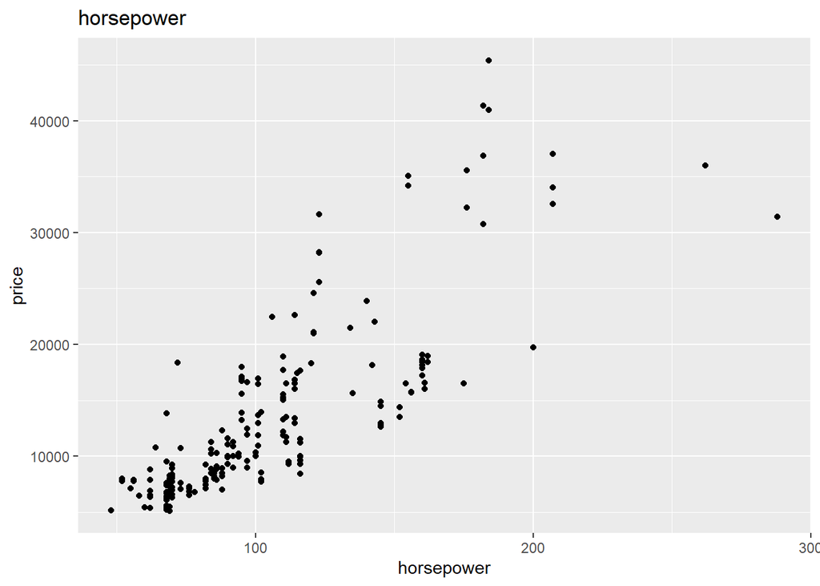

```r
qplot(horsepower, price , data = carData, main="horsepower")
```

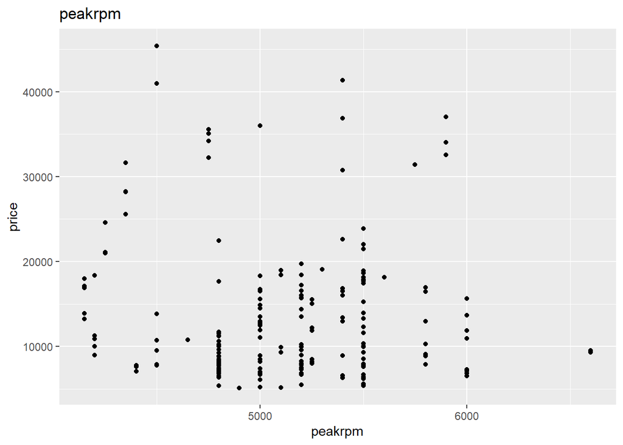

```r
qplot(peakrpm, price , data = carData, main="peakrpm")
```

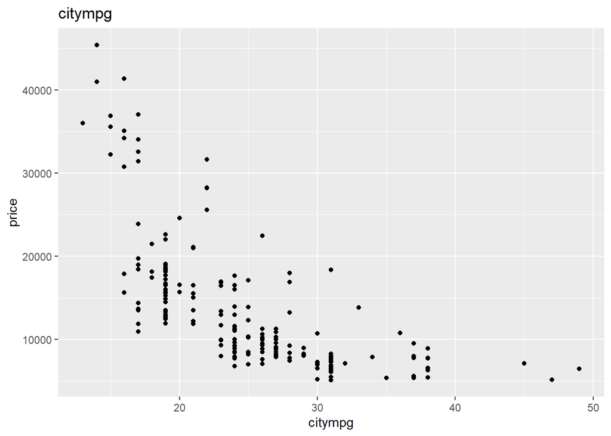

```r
qplot(citympg, price , data = carData, main="citympg")
```

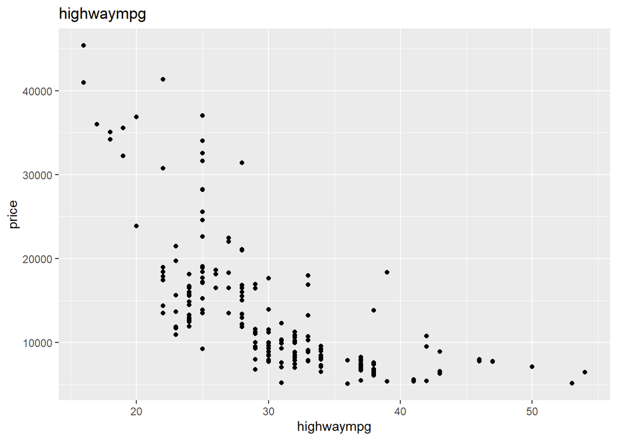

```r
qplot(highwaympg, price , data = carData, main="highwaympg")
```

분석결과 wheelbase, carlength, carwidth, curbweight, enginesize, horsepower 등은 price와 정비례 관계, citympg, highwaympg 등은 반비례 관계인 것을 확인 할 수 있다.

```r
carData.numerical <- carData[,-c(2,3,4,5,6,7,13,14,16)]
#install.packages("corrplot")
#install.packages("magrittr")
library(corrplot) # correlation test and visualization
library(magrittr)
carData.numerical%>%cor.mtest(method='pearson')->p.value
str(p.value)
```

```
## List of 3
##  $ p    : num [1:15, 1:15] 0.00 2.26e-16 1.41e-07 7.77e-04 5.53e-17 ...
##   ..- attr(*, "dimnames")=List of 2
##   .. ..$ : chr [1:15] "symboling" "wheelbase" "carlength" "carwidth" ...
##   .. ..$ : chr [1:15] "symboling" "wheelbase" "carlength" "carwidth" ...
##  $ lowCI: num [1:15, 1:15] 1 -0.624 -0.472 -0.359 -0.631 ...
##   ..- attr(*, "dimnames")=List of 2
##   .. ..$ : chr [1:15] "symboling" "wheelbase" "carlength" "carwidth" ...
##   .. ..$ : chr [1:15] "symboling" "wheelbase" "carlength" "carwidth" ...
##  $ uppCI: num [1:15, 1:15] 1 -0.426 -0.232 -0.099 -0.436 ...
##   ..- attr(*, "dimnames")=List of 2
##   .. ..$ : chr [1:15] "symboling" "wheelbase" "carlength" "carwidth" ...
##   .. ..$ : chr [1:15] "symboling" "wheelbase" "carlength" "carwidth" ...
```

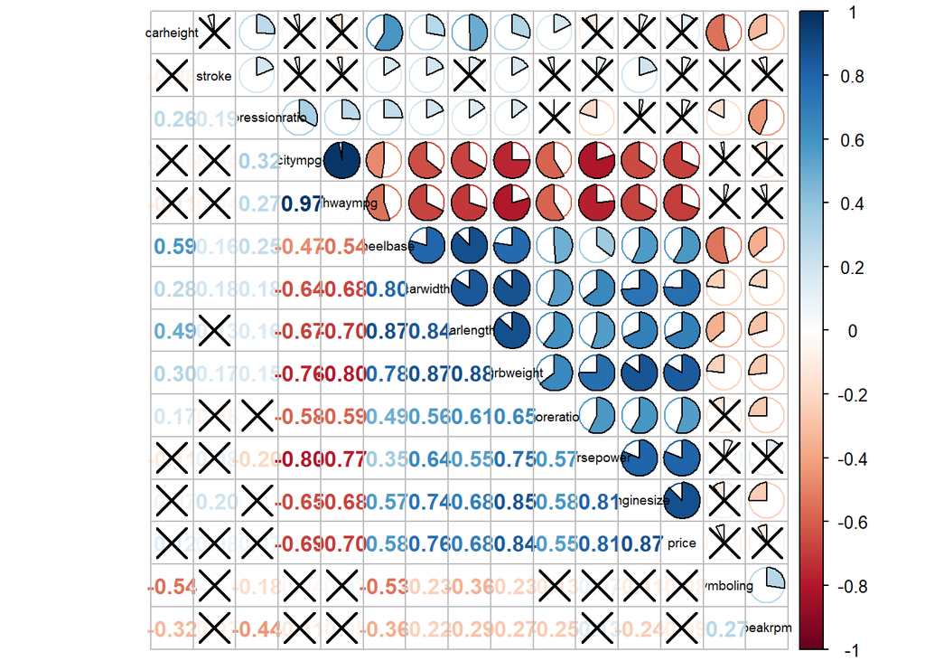

```r
carData.numerical %>% na.omit%>%cor %>% corrplot.mixed(p.mat=p.value[[1]], sig.level=.05, lower = 'number', upper='pie', tl.cex=.6, tl.col='black', order='hclust')
```

또한 fueltype, aspiration, doornumber 등의 다양한 Categorical 변수가 존재하므로, 이를 Numerical 변수로 전환해 주어야 한다. 이때 모든 Categorical 변수를 확인해본 결과 모두 Nominal Data 이므로, One-Hot-Encoding을 적용하기로 하였다.

```r
library(caret) #caret 라이브러리를 활용하여 One-Hot_Encoding 진행
dummy <- dummyVars(" ~ .", data = carData)
carData.new <- data.frame(predict(dummy, newdata= carData))
str(carData.new)
```

```
## 'data.frame':    205 obs. of  53 variables:
##  $ symboling           : num  3 3 1 2 2 2 1 1 1 0 ...
##  $ fueltypediesel      : num  0 0 0 0 0 0 0 0 0 0 ...
##  $ fueltypegas         : num  1 1 1 1 1 1 1 1 1 1 ...
##  $ aspirationstd       : num  1 1 1 1 1 1 1 1 0 0 ...
##  $ aspirationturbo     : num  0 0 0 0 0 0 0 0 1 1 ...
##  $ doornumberfour      : num  0 0 0 1 1 0 1 1 1 0 ...
##  $ doornumbertwo       : num  1 1 1 0 0 1 0 0 0 1 ...
##  $ carbodyconvertible  : num  1 1 0 0 0 0 0 0 0 0 ...
##  $ carbodyhardtop      : num  0 0 0 0 0 0 0 0 0 0 ...
##  $ carbodyhatchback    : num  0 0 1 0 0 0 0 0 0 1 ...
##  $ carbodysedan        : num  0 0 0 1 1 1 1 0 1 0 ...
##  $ carbodywagon        : num  0 0 0 0 0 0 0 1 0 0 ...
##  $ drivewheel4wd       : num  0 0 0 0 1 0 0 0 0 1 ...
##  $ drivewheelfwd       : num  0 0 0 1 0 1 1 1 1 0 ...
```

[output cut: 39 more lines]

car_ID, CarName은 삭제되고, Categorical 변수들이 Numerical 데이터로 변환된 것을 확인 할 수있다. 이제 모든 데이터를 표준화 하여 줄 것인데, 이는 선형회귀에서 상당히 유용한 방법이다. 표준화는 caret 라이브러리의 preProcess 기능을 사용하였다.(단 price 값은 표준화를 해서는 안됨으로 빼고 진행하도록 한다.)

```r
price <-carData.new$price
pstd <- caret::preProcess(carData.new, method = c("center","scale"))
carData.std <- predict(pstd, carData.new)
carData.std$price <- price
summary(carData.std)
```

```
##    symboling       fueltypediesel    fueltypegas     aspirationstd
##  Min.   :-2.2759   Min.   :-0.328   Min.   :-3.034   Min.   :-2.1257
##  1st Qu.:-0.6698   1st Qu.:-0.328   1st Qu.: 0.328   1st Qu.: 0.4681
##  Median : 0.1332   Median :-0.328   Median : 0.328   Median : 0.4681
##  Mean   : 0.0000   Mean   : 0.000   Mean   : 0.000   Mean   : 0.0000
##  3rd Qu.: 0.9362   3rd Qu.:-0.328   3rd Qu.: 0.328   3rd Qu.: 0.4681
##  Max.   : 1.7392   Max.   : 3.034   Max.   : 0.328   Max.   : 0.4681
##  aspirationturbo   doornumberfour    doornumbertwo     carbodyconvertible
##  Min.   :-0.4681   Min.   :-1.1276   Min.   :-0.8825   Min.   :-0.1732
##  1st Qu.:-0.4681   1st Qu.:-1.1276   1st Qu.:-0.8825   1st Qu.:-0.1732
##  Median :-0.4681   Median : 0.8825   Median :-0.8825   Median :-0.1732
##  Mean   : 0.0000   Mean   : 0.0000   Mean   : 0.0000   Mean   : 0.0000
##  3rd Qu.:-0.4681   3rd Qu.: 0.8825   3rd Qu.: 1.1276   3rd Qu.:-0.1732
##  Max.   : 2.1257   Max.   : 0.8825   Max.   : 1.1276   Max.   : 5.7450
##  carbodyhardtop   carbodyhatchback   carbodysedan      carbodywagon
##  Min.   :-0.201   Min.   :-0.7183   Min.   :-0.9362   Min.   :-0.3718
##  1st Qu.:-0.201   1st Qu.:-0.7183   1st Qu.:-0.9362   1st Qu.:-0.3718
##  Median :-0.201   Median :-0.7183   Median :-0.9362   Median :-0.3718
##  Mean   : 0.000   Mean   : 0.0000   Mean   : 0.0000   Mean   : 0.0000
##  3rd Qu.:-0.201   3rd Qu.: 1.3853   3rd Qu.: 1.0630   3rd Qu.:-0.3718
##  Max.   : 4.950   Max.   : 1.3853   Max.   : 1.0630   Max.   : 2.6767
##  drivewheel4wd     drivewheelfwd     drivewheelrwd     enginelocationfront
##  Min.   :-0.2138   Min.   :-1.1853   Min.   :-0.7657   Min.   :-8.1857
##  1st Qu.:-0.2138   1st Qu.:-1.1853   1st Qu.:-0.7657   1st Qu.: 0.1216
##  Median :-0.2138   Median : 0.8396   Median :-0.7657   Median : 0.1216
##  Mean   : 0.0000   Mean   : 0.0000   Mean   : 0.0000   Mean   : 0.0000
##  3rd Qu.:-0.2138   3rd Qu.: 0.8396   3rd Qu.: 1.2996   3rd Qu.: 0.1216
##  Max.   : 4.6553   Max.   : 0.8396   Max.   : 1.2996   Max.   : 0.1216
##  enginelocationrear   wheelbase         carlength           carwidth
##  Min.   :-0.1216    Min.   :-2.0188   Min.   :-2.67071   Min.   :-2.6141
##  1st Qu.:-0.1216    1st Qu.:-0.7069   1st Qu.:-0.62812   1st Qu.:-0.8427
##  Median :-0.1216    Median :-0.2917   Median :-0.06884   Median :-0.1901
##  Mean   : 0.0000    Mean   : 0.0000   Mean   : 0.00000   Mean   : 0.0000
##  3rd Qu.:-0.1216    3rd Qu.: 0.6050   3rd Qu.: 0.73361   3rd Qu.: 0.4625
##  Max.   : 8.1857    Max.   : 3.6772   Max.   : 2.75998   Max.   : 2.9798
##    carheight         curbweight      enginetypedohc    enginetypedohcv
##  Min.   :-2.4247   Min.   :-2.0503   Min.   :-0.2487   Min.   :-0.06984
##  1st Qu.:-0.7059   1st Qu.:-0.7885   1st Qu.:-0.2487   1st Qu.:-0.06984
##  Median : 0.1535   Median :-0.2719   Median :-0.2487   Median :-0.06984
##  Mean   : 0.0000   Mean   : 0.0000   Mean   : 0.0000   Mean   : 0.00000
```

[output cut: 43 more lines]

```
##  Max.   :14.24798   Max.   : 2.25312   Max.   : 2.9164   Max.   : 3.2370
##    horsepower         peakrpm           citympg          highwaympg
##  Min.   :-1.4191   Min.   :-2.0443   Min.   :-1.8678   Min.   :-2.1421
##  1st Qu.:-0.8628   1st Qu.:-0.6816   1st Qu.:-0.9507   1st Qu.:-0.8352
##  Median :-0.2306   Median : 0.1570   Median :-0.1864   Median :-0.1091
##  Mean   : 0.0000   Mean   : 0.0000   Mean   : 0.0000   Mean   : 0.0000
##  3rd Qu.: 0.3005   3rd Qu.: 0.7859   3rd Qu.: 0.7307   3rd Qu.: 0.4718
##  Max.   : 4.6501   Max.   : 3.0921   Max.   : 3.6350   Max.   : 3.3760
##      price
##  Min.   : 5118
##  1st Qu.: 7788
##  Median :10295
##  Mean   :13277
##  3rd Qu.:16503
##  Max.   :45400
```

### 3) 학습모델 구축 및 해석

학습하기에 앞서 train dataset과 test dataset을 나누어 주어야 한다. createDatapartition을 사용하여 price의 값 비율이 train data 와 test data에 유사하게 적용되도록 하였다. (train data와 test data의 비율은 7:3이다.)

```r
idx <- createDataPartition(carData.std$price, p =c(0.7,0.3), list = FALSE)

train_df <- carData.std[idx,]
test_df <- carData.std[-idx,]
```

모든 변수를 이용하여 다중선형회귀 모형을 구축하였다. 학습은 train_df를 이용하여 진행하였다.

```r
multi_model <- lm(price ~ ., data = train_df)
summary(multi_model)
```

```
##
## Call:
## lm(formula = price ~ ., data = train_df)
##
## Residuals:
##     Min      1Q  Median      3Q     Max
## -4432.4 -1034.0   -38.6  1025.1  8422.8
##
## Coefficients: (15 not defined because of singularities)
##                      Estimate Std. Error t value Pr(>|t|)
## (Intercept)          13439.42     201.62  66.656  < 2e-16 ***
## symboling              252.49     351.78   0.718 0.474481
## fueltypediesel        2346.26    2682.25   0.875 0.383677
## fueltypegas                NA         NA      NA       NA
## aspirationstd         -842.16     414.30  -2.033 0.044556 *
## aspirationturbo            NA         NA      NA       NA
## doornumberfour        -216.17     352.95  -0.612 0.541524
## doornumbertwo              NA         NA      NA       NA
## carbodyconvertible     483.76     311.72   1.552 0.123637
## carbodyhardtop         -80.56     312.84  -0.257 0.797291
## carbodyhatchback       131.76     485.89   0.271 0.786778
## carbodysedan           487.30     386.90   1.259 0.210593
## carbodywagon               NA         NA      NA       NA
## drivewheel4wd          -93.17     312.91  -0.298 0.766476
## drivewheelfwd         -559.53     427.11  -1.310 0.192992
## drivewheelrwd              NA         NA      NA       NA
## enginelocationfront   -681.49     355.15  -1.919 0.057667 .
## enginelocationrear         NA         NA      NA       NA
## wheelbase              154.87     737.01   0.210 0.833969
## carlength              336.76     752.44   0.448 0.655375
## carwidth              1122.42     614.14   1.828 0.070392 .
## carheight              267.63     393.88   0.679 0.498304
## curbweight            1102.52    1197.96   0.920 0.359472
## enginetypedohc        -163.19    1170.34  -0.139 0.889365
## enginetypedohcv            NA         NA      NA       NA
## enginetypel           -260.92    1060.91  -0.246 0.806196
## enginetypeohc         1825.52    2172.78   0.840 0.402683
## enginetypeohcf         732.77    1321.61   0.554 0.580427
## enginetypeohcv       -1163.36    1245.74  -0.934 0.352473
## enginetyperotor            NA         NA      NA       NA
```

[output cut: 14 more lines]

```
## fuelsystemspdi        -521.95     555.86  -0.939 0.349850
## fuelsystemspfi             NA         NA      NA       NA
## boreratio            -2326.52     778.03  -2.990 0.003459 **
## stroke               -2308.77     460.86  -5.010 2.17e-06 ***
## compressionratio     -1795.97    2563.27  -0.701 0.485039
## horsepower            1050.85    1063.82   0.988 0.325473
## peakrpm               1032.52     370.60   2.786 0.006313 **
## citympg              -1073.52    1138.10  -0.943 0.347675
## highwaympg            1470.01    1103.71   1.332 0.185731
## ---
## Signif. codes:  0 '***' 0.001 '**' 0.01 '*' 0.05 '.' 0.1 ' ' 1
##
## Residual standard error: 2237 on 107 degrees of freedom
## Multiple R-squared:  0.9406, Adjusted R-squared:  0.9201
## F-statistic:  45.8 on 37 and 107 DF,  p-value: < 2.2e-16
```

### 4) 선형회귀 결과해석

MSE는 Mean Sqaure Error로 실제 Y값에서 예측값을 뺀것의 제곱을 모두 더한 것이다. 해당 값의 측정은 test_df를 이용해서 진행한다.

```r
y_pred <-predict(multi_model , test_df)
mean((test_df$price - y_pred)^2)
```

```
## [1] 26870935
```

MAE는 Mean Absolute Error로 실제 Y 값에서 예측값을 뺀준 것에 절댓값을 취해준 것을 모두 더한 것이다.

```r
#install.packages("Metrics")
library(Metrics)
y_pred <-predict(multi_model , test_df)
mae(test_df$price, y_pred)
```

```
## [1] 2477.577
```

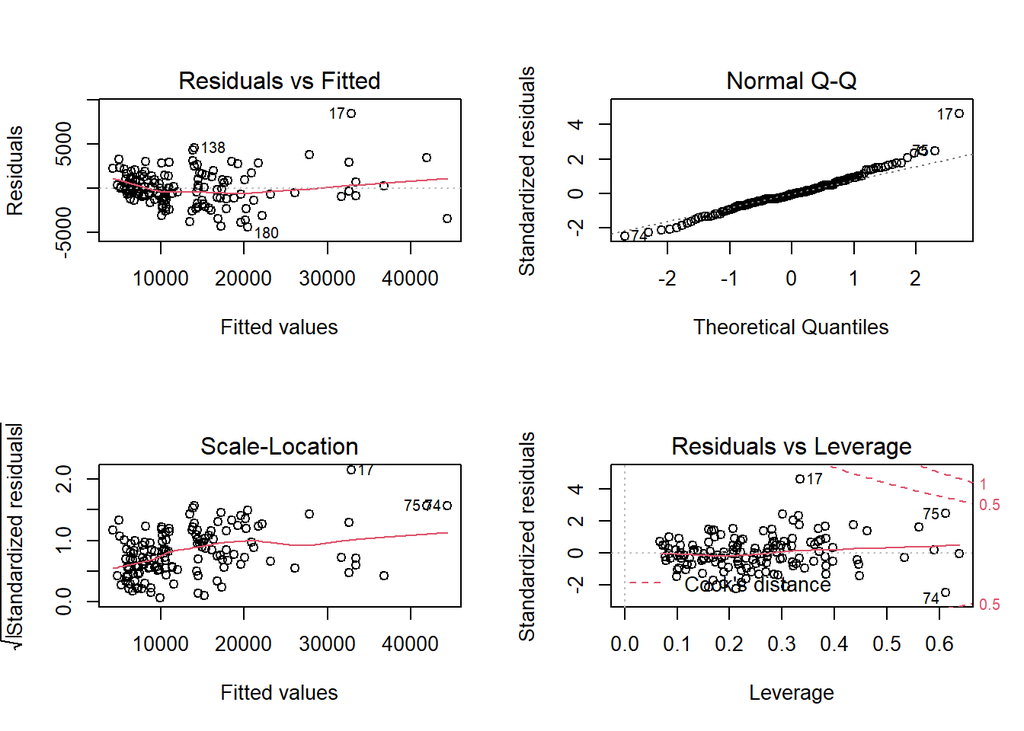

```r
par(mfrow = c(2,2))
plot(multi_model)
```

### 5) 변수선택법을 사용하여 정확도를 향상

수업시간에 배운 내용 중 Stepwise selection을 적용해서 정확도 향상을 시도해보자.

```r
new_model <- step(multi_model, direction = "both")
```

```r
summary(new_model)
```

```
##
## Call:
## lm(formula = price ~ fueltypediesel + aspirationstd + carbodyconvertible +
##     carbodysedan + enginelocationfront + carwidth + curbweight +
##     enginetypeohc + enginetypeohcf + enginetypeohcv + cylindernumbereight +
##     cylindernumberfive + cylindernumberfour + cylindernumbersix +
##     enginesize + fuelsystemspdi + boreratio + stroke + horsepower +
##     peakrpm, data = train_df)
##
## Residuals:
##     Min      1Q  Median      3Q     Max
## -4540.4 -1001.4  -130.6  1234.7  8794.0
##
## Coefficients:
##                     Estimate Std. Error t value Pr(>|t|)
## (Intercept)          13422.4      185.6  72.332  < 2e-16 ***
## fueltypediesel         520.4      303.0   1.717 0.088390 .
## aspirationstd         -815.6      314.8  -2.591 0.010728 *
## carbodyconvertible     457.5      212.7   2.151 0.033410 *
## carbodysedan           329.9      195.6   1.687 0.094174 .
## enginelocationfront   -645.7      249.5  -2.588 0.010806 *
## carwidth              1119.4      437.3   2.560 0.011673 *
## curbweight            1239.3      626.0   1.980 0.049959 *
## enginetypeohc         2124.1      335.3   6.335 3.99e-09 ***
## enginetypeohcf         611.1      335.6   1.821 0.071065 .
## enginetypeohcv       -1121.3      276.9  -4.049 8.99e-05 ***
## cylindernumbereight  -2321.7      963.9  -2.409 0.017482 *
## cylindernumberfive   -3357.0      657.2  -5.108 1.19e-06 ***
## cylindernumberfour   -5095.5      846.4  -6.020 1.83e-08 ***
## cylindernumbersix    -4760.6     1104.7  -4.310 3.30e-05 ***
## enginesize            8743.0     1331.1   6.568 1.26e-09 ***
## fuelsystemspdi        -656.8      210.4  -3.122 0.002239 **
## boreratio            -2167.8      629.7  -3.442 0.000787 ***
## stroke               -2498.1      387.8  -6.441 2.37e-09 ***
## horsepower            1474.9      748.4   1.971 0.050976 .
## peakrpm                978.3      285.2   3.430 0.000822 ***
## ---
## Signif. codes:  0 '***' 0.001 '**' 0.01 '*' 0.05 '.' 0.1 ' ' 1
##
## Residual standard error: 2138 on 124 degrees of freedom
## Multiple R-squared:  0.9372, Adjusted R-squared:  0.927
## F-statistic: 92.47 on 20 and 124 DF,  p-value: < 2.2e-16
```

## 3. 로지스틱 회귀 분석

### 1) 데이터 수집 및 전처리

로지스틱 회귀 분석에 사용한 Data Set은 Kaggle에 존재하는 Data Set으로 여러 지표를 이용하여 심장병을 예측하는 모델을 구축하는데 사용하는 Data 이다. R studio에 HeartDisease로 저장하였다.

```r
HeartDisease <- read.csv("C:/Users/okchr/framingham.csv")
str(HeartDisease)
```

```
## 'data.frame':    4238 obs. of  16 variables:
##  $ male           : int  1 0 1 0 0 0 0 0 1 1 ...
##  $ age            : int  39 46 48 61 46 43 63 45 52 43 ...
##  $ education      : int  4 2 1 3 3 2 1 2 1 1 ...
##  $ currentSmoker  : int  0 0 1 1 1 0 0 1 0 1 ...
##  $ cigsPerDay     : int  0 0 20 30 23 0 0 20 0 30 ...
##  $ BPMeds         : int  0 0 0 0 0 0 0 0 0 0 ...
##  $ prevalentStroke: int  0 0 0 0 0 0 0 0 0 0 ...
##  $ prevalentHyp   : int  0 0 0 1 0 1 0 0 1 1 ...
##  $ diabetes       : int  0 0 0 0 0 0 0 0 0 0 ...
##  $ totChol        : int  195 250 245 225 285 228 205 313 260 225 ...
##  $ sysBP          : num  106 121 128 150 130 ...
##  $ diaBP          : num  70 81 80 95 84 110 71 71 89 107 ...
##  $ BMI            : num  27 28.7 25.3 28.6 23.1 ...
##  $ heartRate      : int  80 95 75 65 85 77 60 79 76 93 ...
##  $ glucose        : int  77 76 70 103 85 99 85 78 79 88 ...
##  $ TenYearCHD     : int  0 0 0 1 0 0 1 0 0 0 ...
```

### 2) 탐색적 데이터 분석

위와 마찬가지로, 범주형 변수 처리와, 정규화 스케일링을 하기에 앞서 데이터 분석을 진행하도록 하겠다.

1.male: 성별을 나타내는 변수. 남자이면 1 여자이면 0이다. (Nominal) 2.age: 환자의 나이.(Continuous - 정수형이지만, 개념은 COntinuous하다.) 3.education: 정확한 데이터를 찾을 수 없음. 4.currentSmoker: 현재 담배를 피고 있는지(1) 혹은 아닌지(0)를 나타낸다.(Nominal) 5.cigsPerDay: 하루에 피우는 담배의 개수.(Continuous) 6.BPMeds: 혈압약을 복용했는지 여부(Nominal) 7.prevalentStroke: 담배를 과거에 피운적이 있는지 여부(Nominal) 8.prevalentHyp: 고혈압 여부(Nominal) 9.diabetes:당뇨병 여부(Nomial) 10.totChol: 총 콜레스테롤 수치(Continuous) 11.sysBP: 수축기 혈압(Continuous) 12.diaBP: 확장기 혈압(Continuous) 13.BMI: 체질량 지수(Continuous) 14.heartRate: 심박수(Continuous > 의학 연구에서, 심장 박동수와 같은 변수는 사실 이산적이지만, 가능한 많은 수 때문에 연속적인 것으로 간주된다.) 15.Glucose: 글루코오스 농도(Continuous) 16.TenYearCHD: 10년 내에 관상 동맥 심장 질환(CDH)에 걸렸는지에 대한 변수.(Nominal)

해당 변수중, education은 정확한 정보가 없으며, 교육과 심장병과의 관계가 미비할 것으로 사료되어 해당 변수를 먼저 제거 하기로 하였다.

```r
HeartDisease <- HeartDisease[,-c(3)] #car_ID, CarName 제거
str(HeartDisease)
```

```
## 'data.frame':    4238 obs. of  15 variables:
##  $ male           : int  1 0 1 0 0 0 0 0 1 1 ...
##  $ age            : int  39 46 48 61 46 43 63 45 52 43 ...
##  $ currentSmoker  : int  0 0 1 1 1 0 0 1 0 1 ...
##  $ cigsPerDay     : int  0 0 20 30 23 0 0 20 0 30 ...
##  $ BPMeds         : int  0 0 0 0 0 0 0 0 0 0 ...
##  $ prevalentStroke: int  0 0 0 0 0 0 0 0 0 0 ...
##  $ prevalentHyp   : int  0 0 0 1 0 1 0 0 1 1 ...
##  $ diabetes       : int  0 0 0 0 0 0 0 0 0 0 ...
##  $ totChol        : int  195 250 245 225 285 228 205 313 260 225 ...
##  $ sysBP          : num  106 121 128 150 130 ...
##  $ diaBP          : num  70 81 80 95 84 110 71 71 89 107 ...
##  $ BMI            : num  27 28.7 25.3 28.6 23.1 ...
##  $ heartRate      : int  80 95 75 65 85 77 60 79 76 93 ...
##  $ glucose        : int  77 76 70 103 85 99 85 78 79 88 ...
##  $ TenYearCHD     : int  0 0 0 1 0 0 1 0 0 0 ...
```

해당 DataSet의 결측치를 확인해 보자.

```r
colSums(is.na(HeartDisease))
```

```
##            male             age   currentSmoker      cigsPerDay          BPMeds
##               0               0               0              29              53
## prevalentStroke    prevalentHyp        diabetes         totChol           sysBP
##               0               0               0              50               0
##           diaBP             BMI       heartRate         glucose      TenYearCHD
##               0              19               1             388               0
```

```r
HeartDisease <- na.omit(HeartDisease)
colSums(is.na(HeartDisease))
```

```
##            male             age   currentSmoker      cigsPerDay          BPMeds
##               0               0               0               0               0
## prevalentStroke    prevalentHyp        diabetes         totChol           sysBP
##               0               0               0               0               0
##           diaBP             BMI       heartRate         glucose      TenYearCHD
##               0               0               0               0               0
```

위와 같이 모든 결측치가 포함된 행을 성공적으로 제거한 것을 확인 할 수 있다.  
이제 각 변수에 의한 CDH 값을 확인해 보도록 하자.

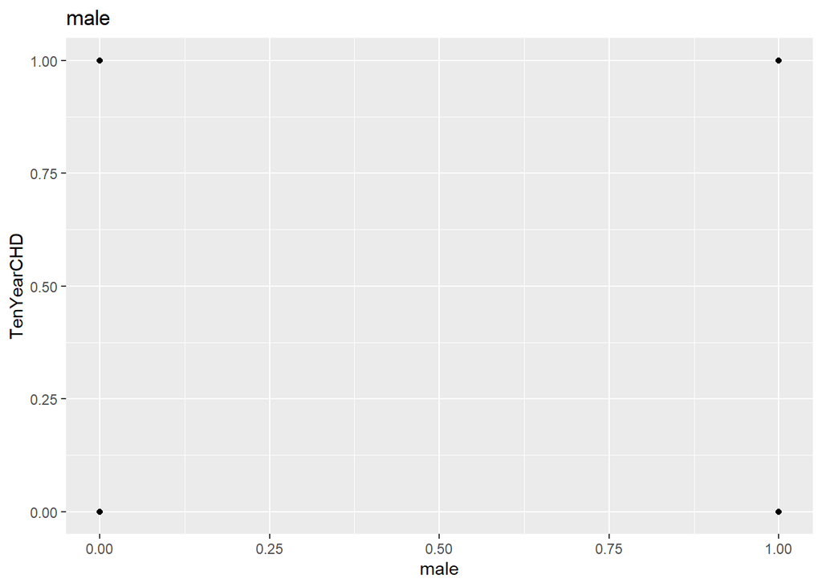

```r
qplot( male ,  TenYearCHD , data = HeartDisease, main="male ")
```

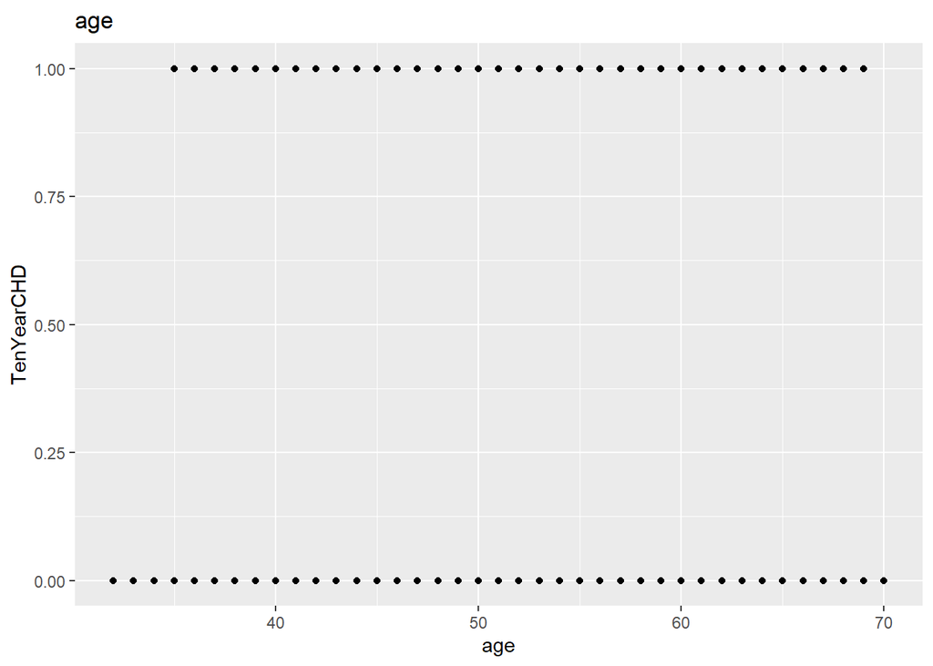

```r
qplot( age ,  TenYearCHD , data = HeartDisease, main="age ")
```

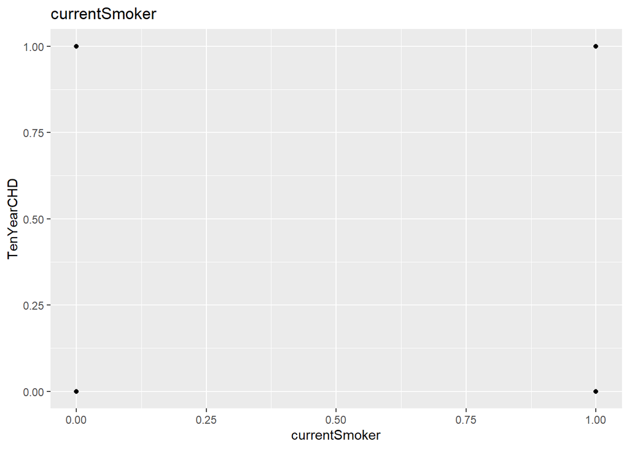

```r
qplot( currentSmoker,  TenYearCHD , data = HeartDisease, main="currentSmoker")
```

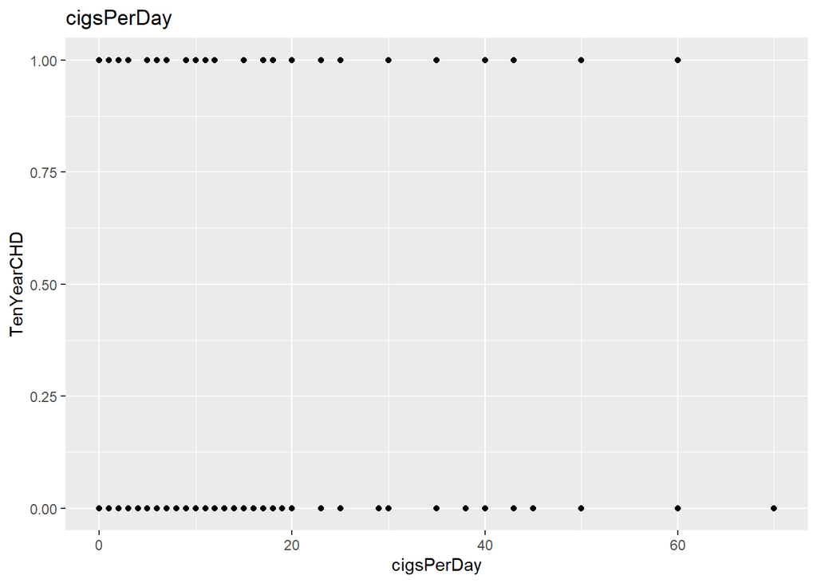

```r
qplot( cigsPerDay,  TenYearCHD , data = HeartDisease, main="cigsPerDay")
```

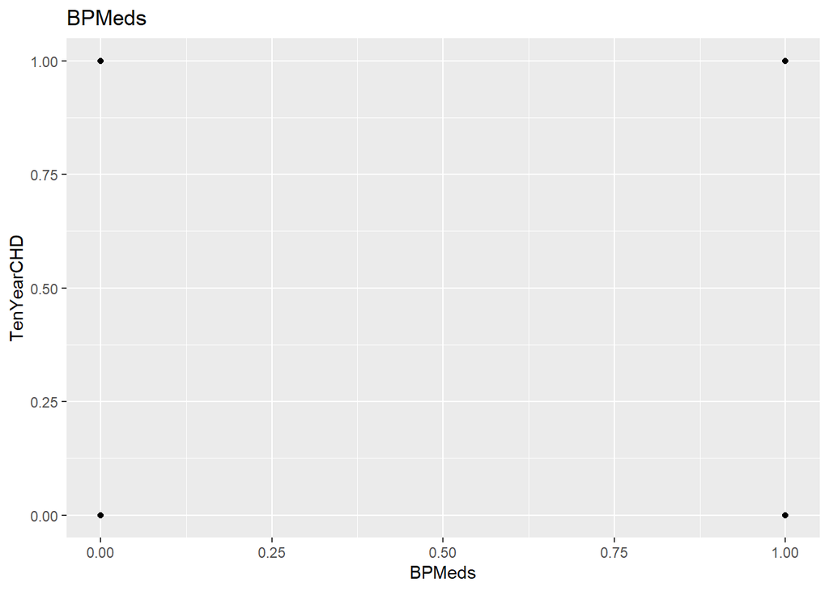

```r
qplot( BPMeds,  TenYearCHD , data = HeartDisease, main="BPMeds")
```

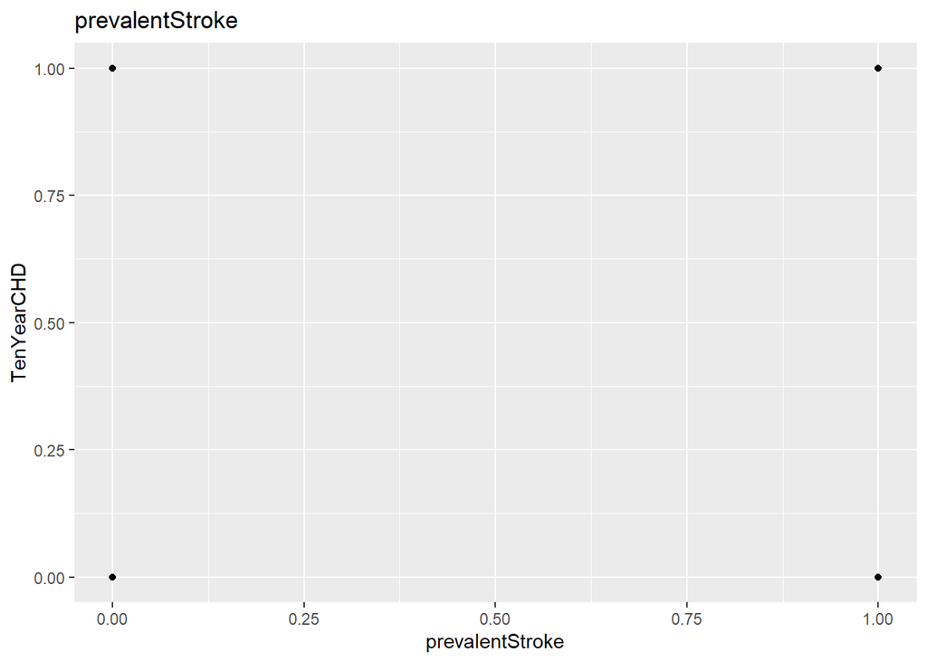

```r
qplot( prevalentStroke,  TenYearCHD , data = HeartDisease, main="prevalentStroke")
```

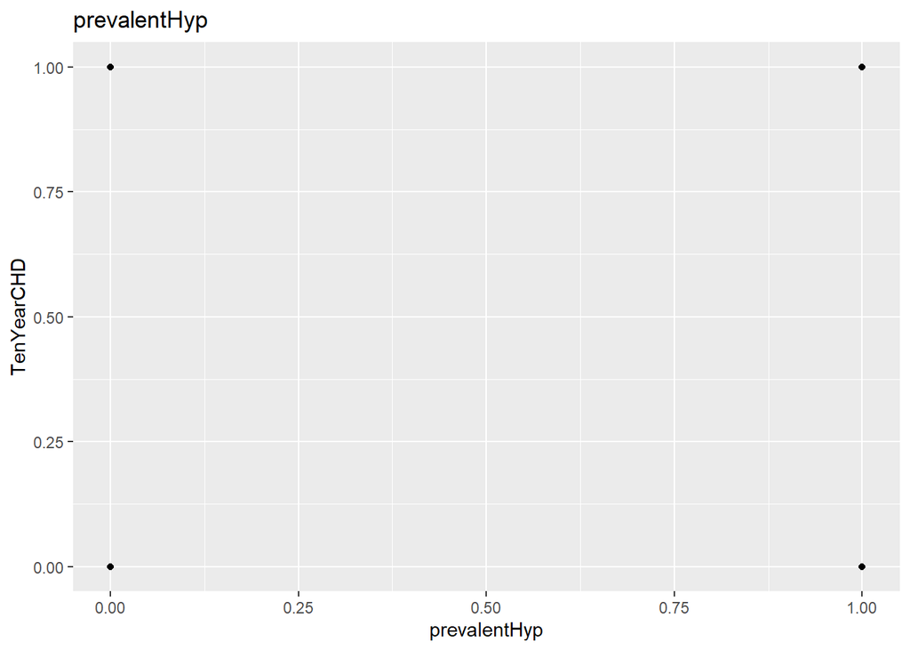

```r
qplot( prevalentHyp,  TenYearCHD , data = HeartDisease, main="prevalentHyp")
```

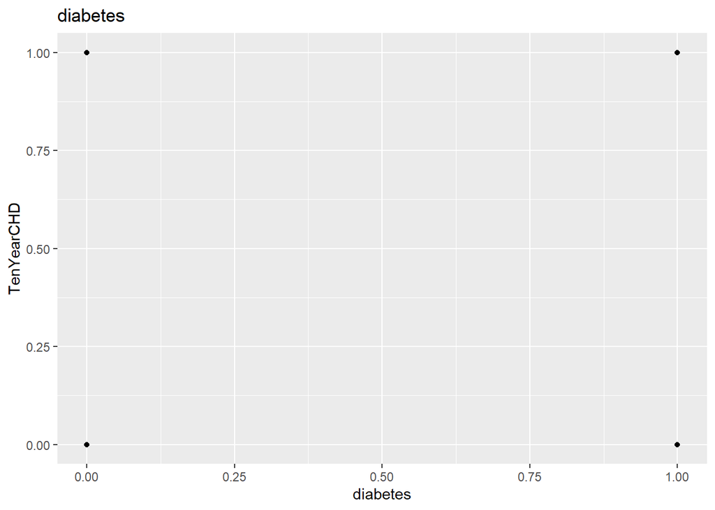

```r
qplot( diabetes ,  TenYearCHD , data = HeartDisease, main="diabetes ")
```

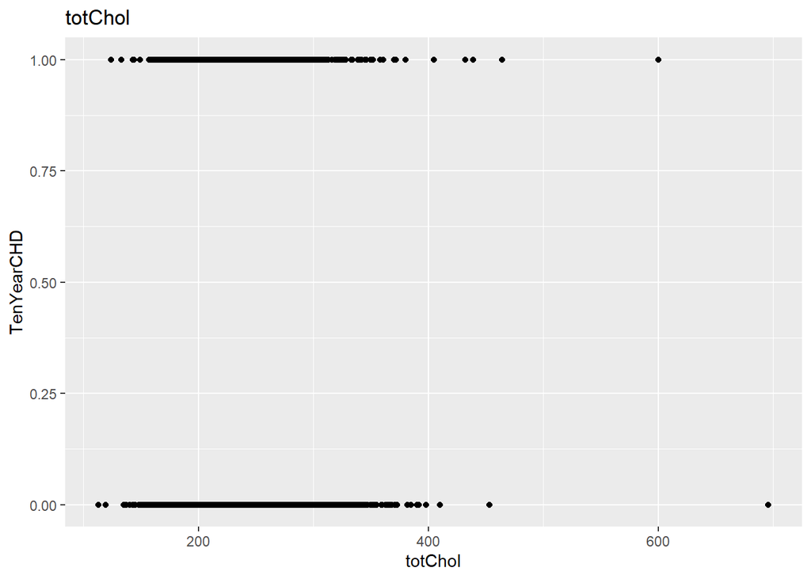

```r
qplot( totChol ,  TenYearCHD , data = HeartDisease, main="totChol ")
```

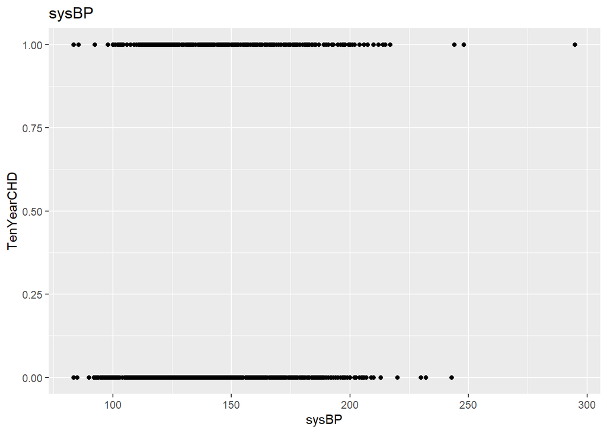

```r
qplot( sysBP,  TenYearCHD , data = HeartDisease, main="sysBP")
```

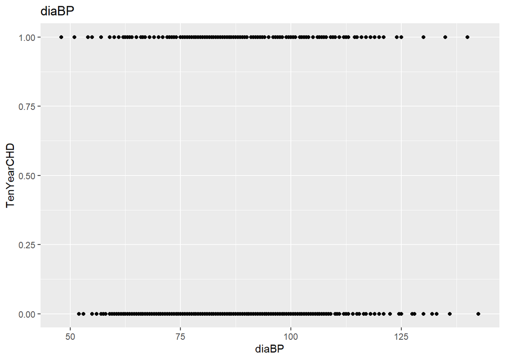

```r
qplot( diaBP,  TenYearCHD , data = HeartDisease, main="diaBP")
```

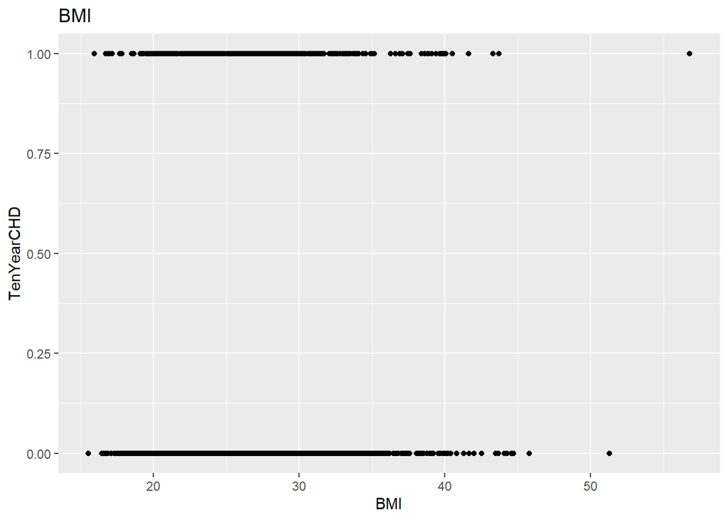

```r
qplot( BMI,  TenYearCHD , data = HeartDisease, main="BMI")
```

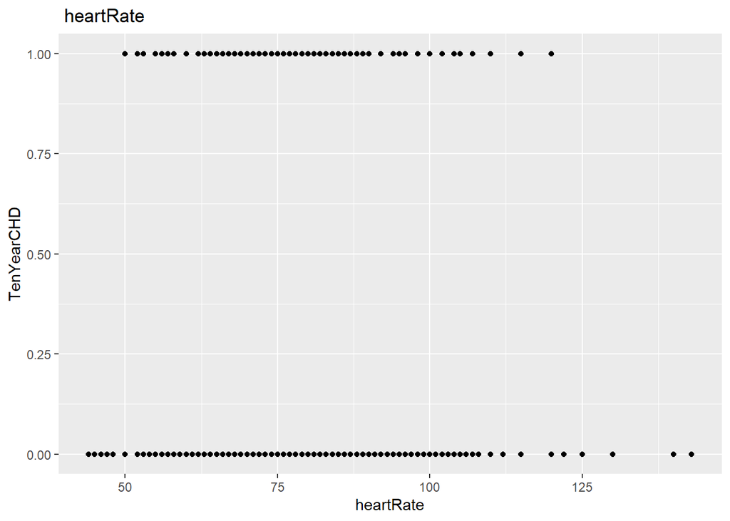

```r
qplot(  heartRate,  TenYearCHD , data = HeartDisease, main=" heartRate")
```

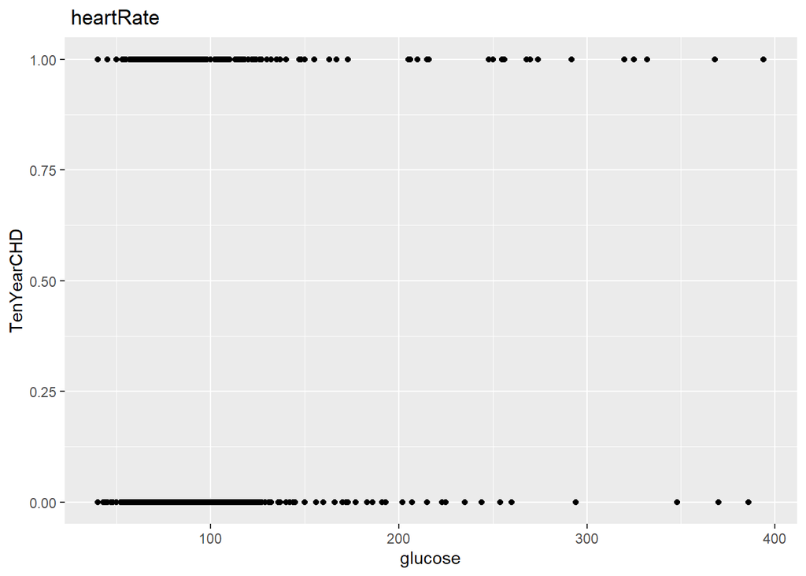

```r
qplot(  glucose ,  TenYearCHD , data = HeartDisease, main=" heartRate")
```

이전 선형회귀와 달리 눈에 보이는 선형적인 관계를 찾기는 어려운 것 같다.

연속형 변수간의 상관계수를 나타내면 아래와 같이 나타낼 수 있다.

```r
HeartDisease.numerical <- HeartDisease[,-c(1,3,5,6,7,8,15)]
HeartDisease.numerical%>%cor.mtest(method='pearson')->p.value
str(p.value)
```

```
## List of 3
##  $ p    : num [1:8, 1:8] 0.00 2.31e-31 2.03e-59 2.27e-135 3.95e-37 ...
##   ..- attr(*, "dimnames")=List of 2
##   .. ..$ : chr [1:8] "age" "cigsPerDay" "totChol" "sysBP" ...
##   .. ..$ : chr [1:8] "age" "cigsPerDay" "totChol" "sysBP" ...
##  $ lowCI: num [1:8, 1:8] 1 -0.219 0.231 0.361 0.175 ...
##   ..- attr(*, "dimnames")=List of 2
##   .. ..$ : chr [1:8] "age" "cigsPerDay" "totChol" "sysBP" ...
##   .. ..$ : chr [1:8] "age" "cigsPerDay" "totChol" "sysBP" ...
##  $ uppCI: num [1:8, 1:8] 1 -0.158 0.291 0.415 0.236 ...
##   ..- attr(*, "dimnames")=List of 2
##   .. ..$ : chr [1:8] "age" "cigsPerDay" "totChol" "sysBP" ...
##   .. ..$ : chr [1:8] "age" "cigsPerDay" "totChol" "sysBP" ...
```

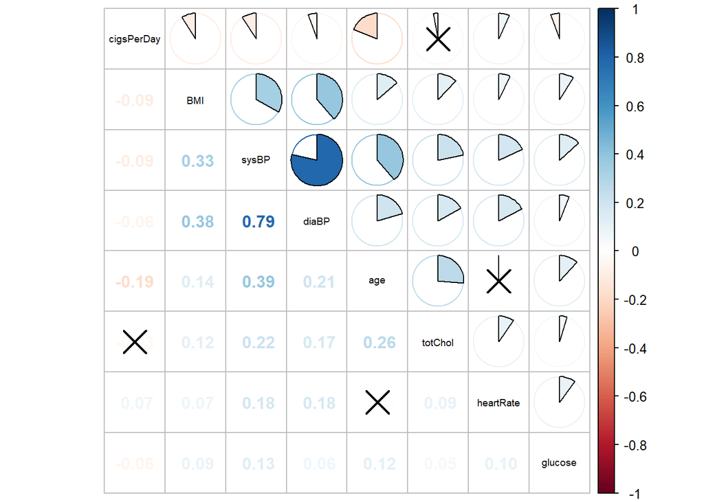

```r
HeartDisease.numerical %>% na.omit%>%cor %>% corrplot.mixed(p.mat=p.value[[1]], sig.level=.05, lower = 'number', upper='pie', tl.cex=.6, tl.col='black', order='hclust')
```

아무래도 sysBp 와 diaBP는 각각, 수축기 이완기의 혈압이다 보니 상관성이 나타나는것 같다.

해당 DataSet의 경우 데이터가 범주형 데이터 일지라도, 이미 숫자로 전환 되어저 있는 상태이고, 카테고리의 개수가 0과 1 두개만 있는 상태이므로 별도의 인코딩 과정은 필요할 것 같지 않다.

앞선 선형회귀에서는 표준화를 사용하였으므로, 이번에는 robust 정규화를 이용해 Scaling을 진행하도록 하겠다.

```r
#HeartDisease$male <- scale(HeartDisease$male, center=median(HeartDisease$male), scale=IQR(HeartDisease$male))
HeartDisease$age <- scale(HeartDisease$age, center=median(HeartDisease$age), scale=IQR(HeartDisease$age))
#HeartDisease$currentSmoker <- scale(HeartDisease$currentSmoker, center=median(HeartDisease$currentSmoker), scale=IQR(HeartDisease$currentSmoker))
HeartDisease$cigsPerDay <- scale(HeartDisease$cigsPerDay, center=median(HeartDisease$cigsPerDay), scale=IQR(HeartDisease$cigsPerDay))
#HeartDisease$BPMeds <- scale(HeartDisease$BPMeds, center=median(HeartDisease$BPMeds), scale=IQR(HeartDisease$BPMeds))
#HeartDisease$prevalentStroke <- scale(HeartDisease$prevalentStroke, center=median(HeartDisease$prevalentStroke), scale=IQR(HeartDisease$prevalentStroke))
#HeartDisease$prevalentHyp <- scale(HeartDisease$prevalentHyp, center=median(HeartDisease$prevalentHyp), scale=IQR(HeartDisease$prevalentHyp))
#HeartDisease$diabetes <- scale(HeartDisease$diabetes, center=median(HeartDisease$diabetes), scale=IQR(HeartDisease$diabetes))
HeartDisease$totChol <- scale(HeartDisease$totChol, center=median(HeartDisease$totChol), scale=IQR(HeartDisease$totChol))
HeartDisease$sysBP <- scale(HeartDisease$sysBP, center=median(HeartDisease$sysBP), scale=IQR(HeartDisease$sysBP))
HeartDisease$diaBP <- scale(HeartDisease$diaBP, center=median(HeartDisease$diaBP), scale=IQR(HeartDisease$diaBP))
HeartDisease$BMI <- scale(HeartDisease$BMI, center=median(HeartDisease$BMI), scale=IQR(HeartDisease$BMI))
HeartDisease$heartRate <- scale(HeartDisease$heartRate, center=median(HeartDisease$heartRate), scale=IQR(HeartDisease$heartRate))
HeartDisease$glucose <- scale(HeartDisease$glucose, center=median(HeartDisease$glucose), scale=IQR(HeartDisease$glucose))

summary(HeartDisease)
```

```
##       male               age.V1        currentSmoker      cigsPerDay.V1
##  Min.   :0.0000   Min.   :-1.2142857   Min.   :0.0000   Min.   :0.000000
##  1st Qu.:0.0000   1st Qu.:-0.5000000   1st Qu.:0.0000   1st Qu.:0.000000
##  Median :0.0000   Median : 0.0000000   Median :0.0000   Median :0.000000
##  Mean   :0.4452   Mean   : 0.0413444   Mean   :0.4884   Mean   :0.450267
##  3rd Qu.:1.0000   3rd Qu.: 0.5000000   3rd Qu.:1.0000   3rd Qu.:1.000000
##  Max.   :1.0000   Max.   : 1.5000000   Max.   :1.0000   Max.   :3.500000
##      BPMeds        prevalentStroke     prevalentHyp       diabetes
##  Min.   :0.00000   Min.   :0.000000   Min.   :0.0000   Min.   :0.00000
##  1st Qu.:0.00000   1st Qu.:0.000000   1st Qu.:0.0000   1st Qu.:0.00000
##  Median :0.00000   Median :0.000000   Median :0.0000   Median :0.00000
##  Mean   :0.03041   Mean   :0.005601   Mean   :0.3118   Mean   :0.02721
##  3rd Qu.:0.00000   3rd Qu.:0.000000   3rd Qu.:1.0000   3rd Qu.:0.00000
##  Max.   :1.00000   Max.   :1.000000   Max.   :1.0000   Max.   :1.00000
##      totChol.V1           sysBP.V1            diaBP.V1
##  Min.   :-2.086207   Min.   :-1.648148   Min.   :-2.266667
##  1st Qu.:-0.482759   1st Qu.:-0.407407   1st Qu.:-0.466667
##  Median : 0.000000   Median : 0.000000   Median : 0.000000
##  Mean   : 0.050910   Mean   : 0.161702   Mean   : 0.062248
##  3rd Qu.: 0.517241   3rd Qu.: 0.592593   3rd Qu.: 0.533333
##  Max.   : 7.965517   Max.   : 6.185185   Max.   : 4.033333
##        BMI.V1           heartRate.V1         glucose.V1        TenYearCHD
##  Min.   :-1.985915   Min.   :-2.214286   Min.   :-2.375000   Min.   :0.0000
##  1st Qu.:-0.466801   1st Qu.:-0.500000   1st Qu.:-0.437500   1st Qu.:0.0000
##  Median : 0.000000   Median : 0.000000   Median : 0.000000   Median :0.0000
##  Mean   : 0.080413   Mean   : 0.050280   Mean   : 0.242698   Mean   :0.1526
##  3rd Qu.: 0.533199   3rd Qu.: 0.500000   3rd Qu.: 0.562500   3rd Qu.:0.0000
##  Max.   : 6.315895   Max.   : 4.857143   Max.   :19.750000   Max.   :1.0000
```

### 3) 학습모델 구축 및 해석

선형회귀와 마찬가지로 train dataset과 test dataset을 나누어 준다.

```r
HeartDisease$TenYearCHD <- as.numeric(HeartDisease$TenYearCHD)
idx <- createDataPartition(HeartDisease$TenYearCHD, p =c(0.7,0.3), list = FALSE)

train_df <- HeartDisease[idx,]
test_df <- HeartDisease[-idx,]
```

모든 변수를 이용하여 로지스틱 선형회귀 모델을 구축한다.

```r
model <- glm(TenYearCHD ~ ., data =train_df, family = "binomial")
summary(model)
```

```
##
## Call:
## glm(formula = TenYearCHD ~ ., family = "binomial", data = train_df)
##
## Deviance Residuals:
##     Min       1Q   Median       3Q      Max
## -1.3665  -0.5938  -0.4341  -0.2978   2.8039
##
## Coefficients:
##                 Estimate Std. Error z value Pr(>|z|)
## (Intercept)     -2.56955    0.12254 -20.969  < 2e-16 ***
## male             0.51792    0.12799   4.047  5.2e-05 ***
## age              0.86273    0.10974   7.861  3.8e-15 ***
## currentSmoker   -0.06759    0.18529  -0.365 0.715275
## cigsPerDay       0.44823    0.14740   3.041 0.002358 **
## BPMeds           0.43977    0.27140   1.620 0.105155
## prevalentStroke  0.44371    0.58551   0.758 0.448559
## prevalentHyp     0.14331    0.16572   0.865 0.387144
## diabetes        -0.07451    0.36792  -0.203 0.839508
## totChol          0.09600    0.07337   1.309 0.190687
## sysBP            0.38385    0.11955   3.211 0.001324 **
## diaBP           -0.12121    0.11206  -1.082 0.279391
## BMI              0.04350    0.07357   0.591 0.554379
## heartRate        0.03898    0.06874   0.567 0.570699
## glucose          0.17028    0.04601   3.701 0.000215 ***
## ---
## Signif. codes:  0 '***' 0.001 '**' 0.01 '*' 0.05 '.' 0.1 ' ' 1
##
## (Dispersion parameter for binomial family taken to be 1)
##
##     Null deviance: 2233.9  on 2624  degrees of freedom
## Residual deviance: 1990.9  on 2610  degrees of freedom
## AIC: 2020.9
##
## Number of Fisher Scoring iterations: 5
```

### 4) 로지스틱회귀 결과해석

```r
perf_eval <- function(cm){
  # true positive rate
  TPR = Recall = cm[2,2]/sum(cm[2,])
  # precision
  Precision = cm[2,2]/sum(cm[,2])
  # true negative rate
  TNR = cm[1,1]/sum(cm[1,])
  # accuracy
  ACC = sum(diag(cm)) / sum(cm)
  # balance corrected accuracy (geometric mean)
  BCR = sqrt(TPR*TNR)
  # f1 measure
  F1 = 2 * Recall * Precision / (Recall + Precision)

  re <- data.frame(TPR = TPR,
                   Precision = Precision,
                   TNR = TNR,
                   ACC = ACC,
                   BCR = BCR,
                   F1 = F1)
  return(re)
}

pred_prob <- predict(model, test_df, type="response")
pred_class <- rep(0, nrow(test_df))
pred_class[pred_prob > 0.5] <- 1
cm <- table(pred=pred_class, actual=test_df$TenYearCHD)
perf_eval(cm)
```

```
##     TPR  Precision       TNR       ACC       BCR        F1
## 1 0.625 0.05747126 0.8519856 0.8487544 0.7297198 0.1052632
```

1.Recall(TPR): 실제로 1일인 것들중에서 1로 예측한 비율  
2.Precision : 1이라고 예측했을 때 실제로 1인 비율  
3.TNR: 실제 값이 0이고,0으로 예측한 비율  
4.ACC : 전체 데이터 중에 정확하게 에측한 데이터의 비율  
5.F1 : Pericision과 Recall 값을 결합한 지표로, 어느 한쪽에 치우친 예측을 하지 않는 경우에 더 높은 값이 나오게 된다.

해당 모델의 경우 Recall 값이 은 0.6~으로 심장병일 확률을 어느정도 잡아내지만, Precision이 낮다는 것은 심장병이 아닌데, 심장병이라고 말할 가능성 또한 놉다는 것이다. 이는 심장병을 심장병이라고 할 비율보다, 아닐때 아니라고 하는 성능이 월등히 좋다는 것을 의미하고 이로 인해서 F1또한 낮아졌다. 이는 Data Set이 애초에 label 값이 0인 것이 훨씬 많기 때문에 발생하는 것으로 사료된다.

### 5) 변수 선택법을 사용하여 정확도 향상

```r
model_fwd <- step(glm(TenYearCHD ~ 1, train_df,
                      family = binomial()),
                  direction = "forward", trace = 0,
                  scope = formula(model))

pred_prob <- predict(model_fwd, test_df, type="response")
pred_class <- rep(0, nrow(test_df))
pred_class[pred_prob > 0.5] <- 1
cm <- table(pred=pred_class, actual=test_df$TenYearCHD)
perf_eval(cm)
```

```
##         TPR  Precision       TNR      ACC       BCR         F1
## 1 0.4736842 0.05172414 0.8506787 0.844306 0.6347859 0.09326425
```

Forward 기법을 이용하여 변수 선택을 진행하였다. 그와 더불어서 Threshold 값을 튜닝해 가면 확인을 해보자.

```r
pred_prob <- predict(model_fwd, test_df, type="response")
pred_class <- rep(0, nrow(test_df))
pred_class[pred_prob > 0.3] <- 1
cm <- table(pred=pred_class, actual=test_df$TenYearCHD)
perf_eval(cm)
```

```
##         TPR Precision   TNR       ACC       BCR        F1
## 1 0.4137931 0.2758621 0.875 0.8274021 0.6017217 0.3310345
```